# Analysis

wk

2026-04-15

### Data Description

```r
#38005 total calves in the data set

full %>%
  group_by(SEX) %>%
  count()
```

```
## # A tibble: 2 × 2
## # Groups:   SEX [2]
##   SEX       n
##   <chr> <int>
## 1 F     31545
## 2 M      6460
```

```r
#31545 heifers and 6460 male calves


full %>%
  group_by(CBRD) %>%
  count()
```

```
## # A tibble: 5 × 2
## # Groups:   CBRD [5]
##   CBRD      n
##   <chr> <int>
## 1 -        56
## 2 D      1691
## 3 H     29265
## 4 J       690
## 5 X      6303
```

```r
full %>%
  group_by(month) %>%
  count()
```

```
## # A tibble: 12 × 2
## # Groups:   month [12]
##    month     n
##    <chr> <int>
##  1 Apr    2706
##  2 Aug    3490
##  3 Dec    2763
##  4 Feb    2713
##  5 Jan    3080
##  6 Jul    3734
##  7 Jun    2987
##  8 Mar    2794
##  9 May    2779
## 10 Nov    3310
## 11 Oct    3862
## 12 Sep    3787
```

```r
full %>%
  group_by(as.factor(comp)) %>%
  count()
```

```
## # A tibble: 8 × 2
## # Groups:   as.factor(comp) [8]
##   `as.factor(comp)`     n
##   <fct>             <int>
## 1 1                  2557
## 2 2                  6362
## 3 3                  6238
## 4 4                  1750
## 5 5                  3529
## 6 6                  6310
## 7 7                  5997
## 8 8                  5262
```

```r
full %>%
  group_by(LOADfull) %>%
  count()
```

```
## # A tibble: 229 × 2
## # Groups:   LOADfull [229]
##    LOADfull       n
##    <chr>      <int>
##  1 2024-11-12   174
##  2 2024-11-14   171
##  3 2024-11-16   189
##  4 2024-11-18   202
##  5 2024-11-20   187
##  6 2024-11-22   181
##  7 2024-11-24   180
##  8 2024-11-26   180
##  9 2024-11-28   177
## 10 2024-11-30   182
## # ℹ 219 more rows
```

```r
full %>%
  group_by(SRCE) %>%
  count()
```

```
## # A tibble: 25 × 2
## # Groups:   SRCE [25]
##     SRCE     n
##    <int> <int>
##  1    11   600
##  2    14  2263
##  3    22   483
##  4    24  1158
##  5    29   991
##  6    31  2331
##  7    32   162
##  8    33   424
##  9    34   923
## 10    38   326
## # ℹ 15 more rows
```

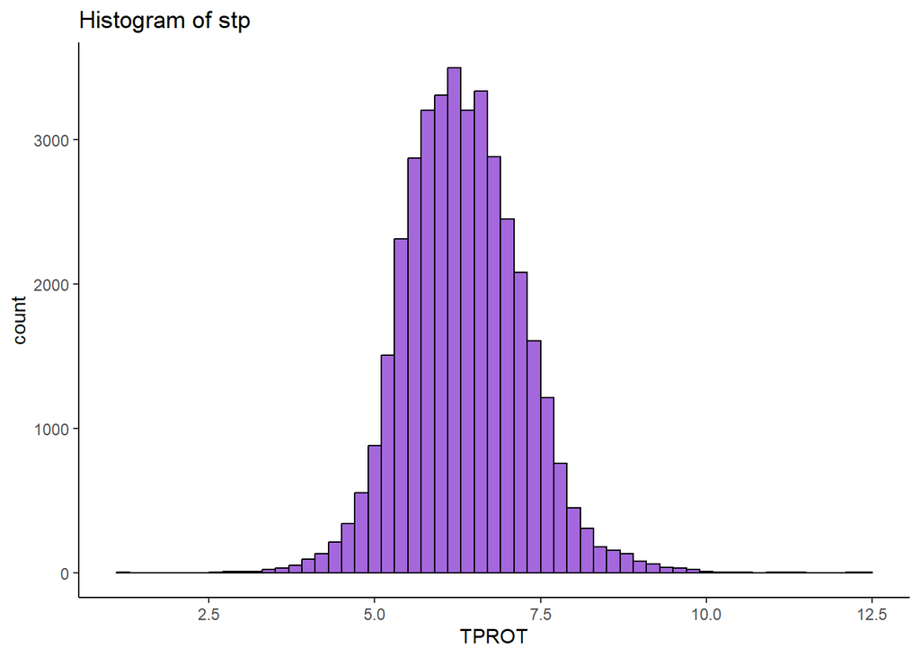

```r
full |>
  ggplot(mapping=aes(TPROT))+
  theme_classic()+
  geom_histogram(binwidth=0.2,
                 fill="purple3",
                 color="black",
                 alpha=0.7)+
  labs(title = "Histogram of stp")
```

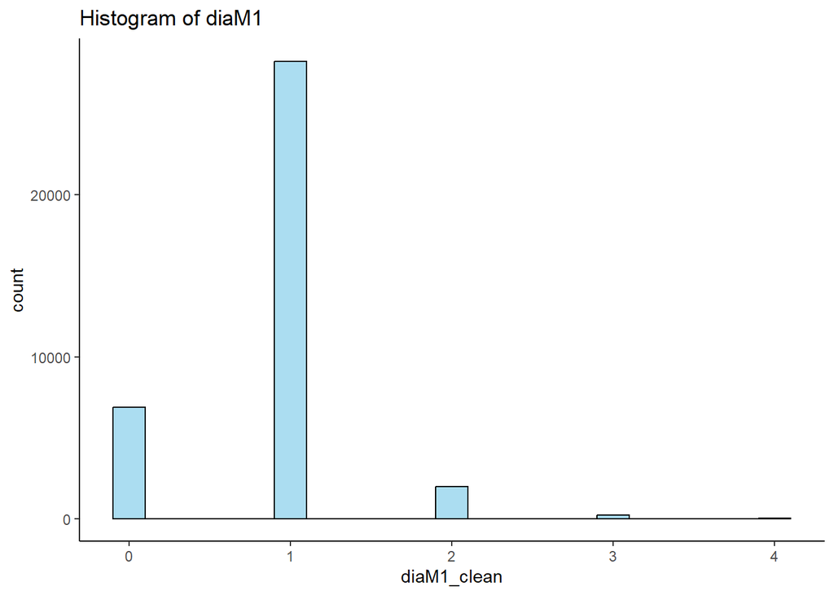

```r
full |>
  ggplot(mapping=aes(diaM1_clean))+
  theme_classic()+
  geom_histogram(binwidth=0.2,
                 fill="skyblue",
                 color="black",
                 alpha=0.7)+
  labs(title = "Histogram of diaM1")
```

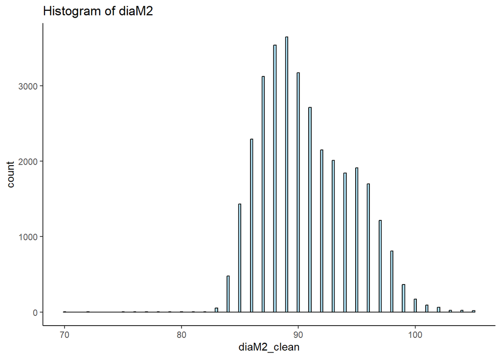

```r
full |>
  ggplot(mapping=aes(diaM2_clean))+
  theme_classic()+
  geom_histogram(binwidth=0.2,
                 fill="skyblue",
                 color="black",
                 alpha=0.7)+
  labs(title = "Histogram of diaM2")
```

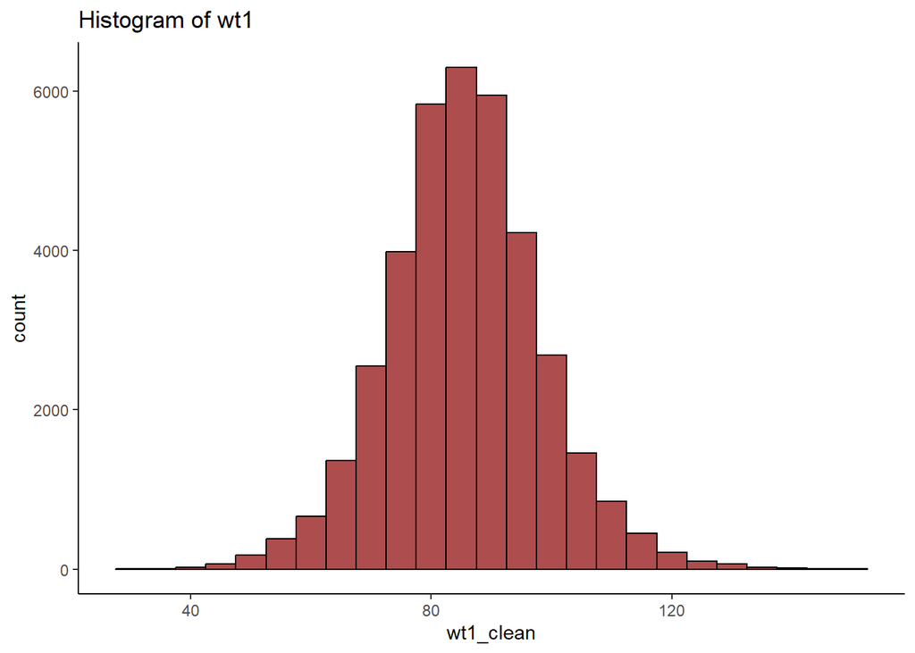

```r
full |>
  ggplot(mapping=aes(wt1_clean))+
  theme_classic()+
  geom_histogram(binwidth=5,
                 fill="red4",
                 color="black",
                 alpha=0.7)+
  labs(title = "Histogram of wt1")
```

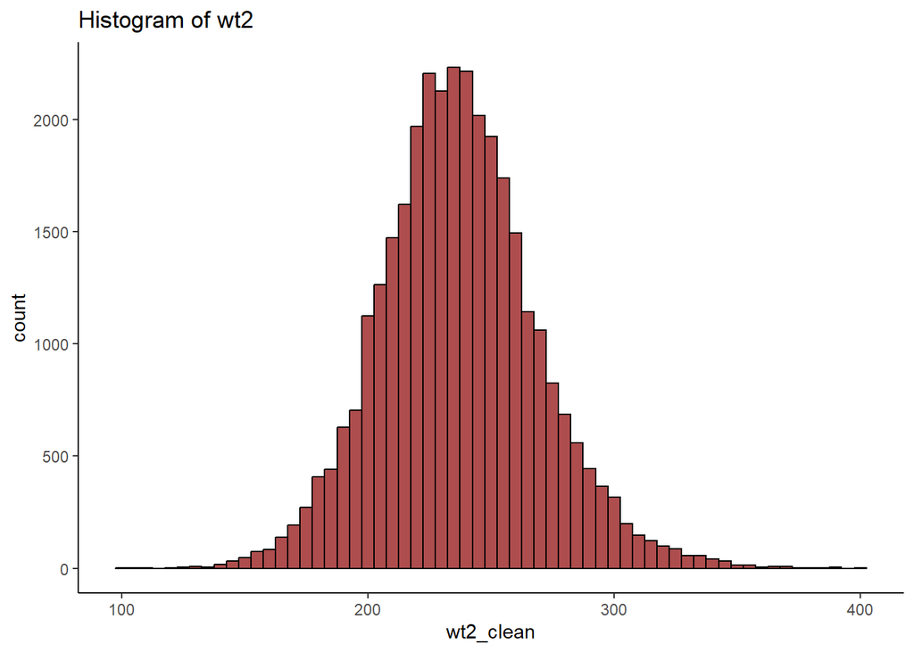

```r
full |>
  ggplot(mapping=aes(wt2_clean))+
  theme_classic()+
  geom_histogram(binwidth=5,
                 fill="red4",
                 color="black",
                 alpha=0.7)+
  labs(title = "Histogram of wt2")
```

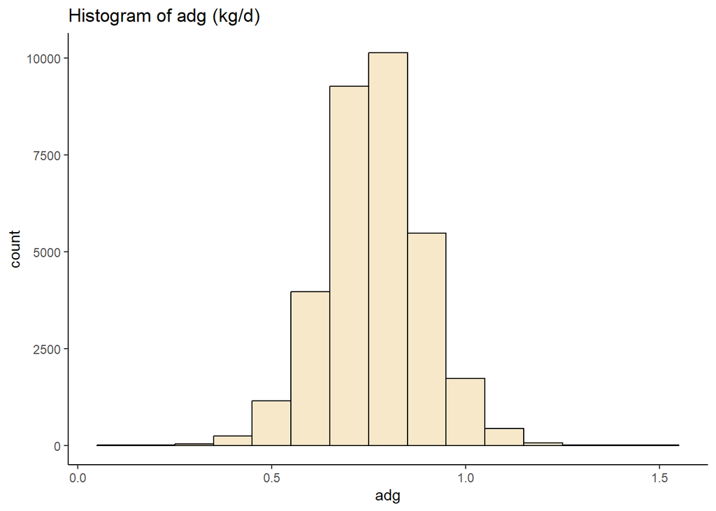

```r
full |>
  ggplot(mapping=aes(adg))+
  theme_classic()+
  geom_histogram(binwidth=0.1,
                 fill="wheat",
                 color="black",
                 alpha=0.7)+
  labs(title = "Histogram of adg (kg/d)")
```

#### Question: Are baseline characteristics of calves different by 1) different compartments; and 2) different SD quartiles (using quart_custom) 3) source farm?

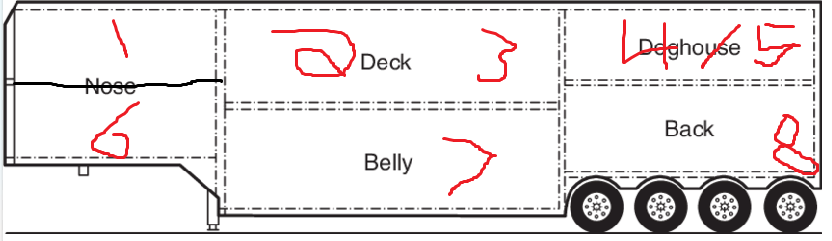

```r
full %>%
  group_by(as.factor(comp)) %>%
  summarize(
    stp = mean(TPROT, na.rm=TRUE),
    diaM1 = mean(diaM1_clean, na.rm=TRUE),
    wt1 = mean(wt1_clean, na.rm=TRUE),
    diaload = mean(diaload, na.rm=TRUE))
```

```
## # A tibble: 8 × 5
##   `as.factor(comp)`   stp diaM1   wt1 diaload
##   <fct>             <dbl> <dbl> <dbl>   <dbl>
## 1 1                  6.48 0.971  86.5    3.44
## 2 2                  6.35 0.890  87.2    3.22
## 3 3                  6.47 0.973  87.4    3.33
## 4 4                  6.47 0.930  86.6    3.48
## 5 5                  6.38 0.851  84.9    3.31
## 6 6                  6.23 0.769  82.3    3.19
## 7 7                  6.38 0.838  84.2    3.23
## 8 8                  6.49 0.913  86.3    3.34
```

```r
table(full$comp, full$SEX)
```

```
##
##        F    M
##   1 1973  584
##   2 4329 2033
##   3 5102 1136
##   4 1370  380
##   5 2904  625
##   6 6134  176
##   7 5540  457
##   8 4193 1069
```

```r
table(full$comp, full$CBRD)
```

```
##
##        -    D    H    J    X
##   1   14  145 1745   84  569
##   2   20  302 4023   29 1988
##   3   14  397 4630   37 1160
##   4    0   69 1279   39  363
##   5    0  102 2748   71  608
##   6    2  199 5772  194  143
##   7    5  315 5061  178  438
##   8    1  162 4007   58 1034
```

```r
table(full$comp, full$month)
```

```
##
##     Apr Aug Dec Feb Jan Jul Jun Mar May Nov Oct Sep
##   1 204 102 274 255 303 139 288 238 203 241 167 143
##   2 390 682 431 403 451 655 426 429 445 565 739 746
##   3 428 655 425 382 452 663 423 417 430 546 721 696
##   4 149  57 169 232 239 196 278 180 110 123  17   0
##   5 278 279 275 263 290 257 272 276 274 319 386 360
##   6 439 663 415 390 461 642 433 428 449 556 722 712
##   7 402 629 399 397 449 611 430 394 431 499 678 678
##   8 416 423 375 391 435 571 437 432 437 461 432 452
```

```r
lm_1 <- lm(TPROT ~ as.factor(comp), data=full)
summary(lm_1)
```

```
##
## Call:
## lm(formula = TPROT ~ as.factor(comp), data = full)
##
## Residuals:
##     Min      1Q  Median      3Q     Max
## -5.1333 -0.5891 -0.0455  0.5545  5.9243
##
## Coefficients:
##                   Estimate Std. Error t value Pr(>|t|)
## (Intercept)       6.475714   0.017310 374.102  < 2e-16 ***
## as.factor(comp)2 -0.130225   0.020495  -6.354 2.12e-10 ***
## as.factor(comp)3 -0.010629   0.020554  -0.517    0.605
## as.factor(comp)4 -0.005085   0.027156  -0.187    0.851
## as.factor(comp)5 -0.090732   0.022732  -3.991 6.58e-05 ***
## as.factor(comp)6 -0.242417   0.020520 -11.814  < 2e-16 ***
## as.factor(comp)7 -0.097458   0.020674  -4.714 2.44e-06 ***
## as.factor(comp)8  0.013378   0.021101   0.634    0.526
## ---
## Signif. codes:  0 '***' 0.001 '**' 0.01 '*' 0.05 '.' 0.1 ' ' 1
##
## Residual standard error: 0.8753 on 37997 degrees of freedom
## Multiple R-squared:  0.009711,   Adjusted R-squared:  0.009528
## F-statistic: 53.23 on 7 and 37997 DF,  p-value: < 2.2e-16
```

```r
lm_2 <- lm(diaM1_clean ~ as.factor(comp), data=full)
summary(lm_2)
```

```
##
## Call:
## lm(formula = diaM1_clean ~ as.factor(comp), data = full)
##
## Residuals:
##     Min      1Q  Median      3Q     Max
## -0.9728  0.0272  0.0867  0.1624  3.2314
##
## Coefficients:
##                   Estimate Std. Error t value Pr(>|t|)
## (Intercept)       0.971020   0.009879  98.289  < 2e-16 ***
## as.factor(comp)2 -0.081207   0.011701  -6.940 3.98e-12 ***
## as.factor(comp)3  0.001799   0.011731   0.153  0.87813
## as.factor(comp)4 -0.040774   0.015433  -2.642  0.00824 **
## as.factor(comp)5 -0.120334   0.012959  -9.286  < 2e-16 ***
## as.factor(comp)6 -0.202412   0.011721 -17.269  < 2e-16 ***
## as.factor(comp)7 -0.133454   0.011811 -11.299  < 2e-16 ***
## as.factor(comp)8 -0.057757   0.012059  -4.790 1.68e-06 ***
## ---
## Signif. codes:  0 '***' 0.001 '**' 0.01 '*' 0.05 '.' 0.1 ' ' 1
##
## Residual standard error: 0.4958 on 37342 degrees of freedom
##   (655 observations deleted due to missingness)
## Multiple R-squared:  0.01866,    Adjusted R-squared:  0.01848
## F-statistic: 101.4 on 7 and 37342 DF,  p-value: < 2.2e-16
```

```r
lm_3 <- lm(wt1_clean ~ as.factor(comp), data=full)
summary(lm_3)
```

```
##
## Call:
## lm(formula = wt1_clean ~ as.factor(comp), data = full)
##
## Residuals:
##     Min      1Q  Median      3Q     Max
## -54.246  -8.152  -0.246   7.746  61.501
##
## Coefficients:
##                  Estimate Std. Error t value Pr(>|t|)
## (Intercept)       86.4994     0.2509 344.748  < 2e-16 ***
## as.factor(comp)2   0.6524     0.2972   2.195  0.02816 *
## as.factor(comp)3   0.8802     0.2979   2.954  0.00314 **
## as.factor(comp)4   0.1055     0.3919   0.269  0.78778
## as.factor(comp)5  -1.6313     0.3291  -4.957 7.21e-07 ***
## as.factor(comp)6  -4.2450     0.2977 -14.260  < 2e-16 ***
## as.factor(comp)7  -2.2538     0.3000  -7.513 5.89e-14 ***
## as.factor(comp)8  -0.2011     0.3063  -0.657  0.51147
## ---
## Signif. codes:  0 '***' 0.001 '**' 0.01 '*' 0.05 '.' 0.1 ' ' 1
##
## Residual standard error: 12.59 on 37342 degrees of freedom
##   (655 observations deleted due to missingness)
## Multiple R-squared:  0.02025,    Adjusted R-squared:  0.02007
## F-statistic: 110.3 on 7 and 37342 DF,  p-value: < 2.2e-16
```

```r
lm_4 <- lm(diaload ~ as.factor(comp), data=full)
summary(lm_4)
```

```
##
## Call:
## lm(formula = diaload ~ as.factor(comp), data = full)
##
## Residuals:
##    Min     1Q Median     3Q    Max
## -3.188 -0.333 -0.224  0.667  2.812
##
## Coefficients:
##                  Estimate Std. Error t value Pr(>|t|)
## (Intercept)       3.44349    0.01420 242.414  < 2e-16 ***
## as.factor(comp)2 -0.21950    0.01682 -13.051  < 2e-16 ***
## as.factor(comp)3 -0.11053    0.01687  -6.553 5.71e-11 ***
## as.factor(comp)4  0.04108    0.02228   1.844   0.0653 .
## as.factor(comp)5 -0.13037    0.01865  -6.989 2.82e-12 ***
## as.factor(comp)6 -0.25601    0.01684 -15.203  < 2e-16 ***
## as.factor(comp)7 -0.20937    0.01697 -12.341  < 2e-16 ***
## as.factor(comp)8 -0.10046    0.01732  -5.802 6.61e-09 ***
## ---
## Signif. codes:  0 '***' 0.001 '**' 0.01 '*' 0.05 '.' 0.1 ' ' 1
##
## Residual standard error: 0.7183 on 37997 degrees of freedom
## Multiple R-squared:  0.01346,    Adjusted R-squared:  0.01327
## F-statistic: 74.04 on 7 and 37997 DF,  p-value: < 2.2e-16
```

```r
full %>%
  group_by(quart_custom) %>%
  summarize(
    stp = mean(TPROT, na.rm=TRUE),
    diaM1 = mean(diaM1_clean, na.rm=TRUE),
    wt1 = mean(wt1_clean, na.rm=TRUE),
    diaload = mean(diaload, na.rm=TRUE))
```

```
## # A tibble: 4 × 5
##   quart_custom   stp diaM1   wt1 diaload
##   <chr>        <dbl> <dbl> <dbl>   <dbl>
## 1 High          6.42 0.926  86.7    3.35
## 2 Low           6.44 0.905  85.5    3.28
## 3 Med           6.37 0.846  85.4    3.31
## 4 Medlow        6.35 0.861  84.8    3.23
```

```r
lm_1 <- lm(TPROT ~ quart_custom, data=full)
summary(lm_1)
```

```
##
## Call:
## lm(formula = TPROT ~ quart_custom, data = full)
##
## Residuals:
##     Min      1Q  Median      3Q     Max
## -5.2679 -0.6184 -0.0463  0.5639  5.9639
##
## Coefficients:
##                     Estimate Std. Error t value Pr(>|t|)
## (Intercept)         6.418404   0.009921 646.968  < 2e-16 ***
## quart_customLow     0.017714   0.013300   1.332  0.18293
## quart_customMed    -0.050478   0.013473  -3.746  0.00018 ***
## quart_customMedlow -0.072077   0.012979  -5.554 2.82e-08 ***
## ---
## Signif. codes:  0 '***' 0.001 '**' 0.01 '*' 0.05 '.' 0.1 ' ' 1
##
## Residual standard error: 0.8788 on 38001 degrees of freedom
## Multiple R-squared:  0.001797,   Adjusted R-squared:  0.001718
## F-statistic:  22.8 on 3 and 38001 DF,  p-value: 9.695e-15
```

```r
lm_2 <- lm(diaM1_clean ~ quart_custom, data=full)
summary(lm_2)
```

```
##
## Call:
## lm(formula = diaM1_clean ~ quart_custom, data = full)
##
## Residuals:
##      Min       1Q   Median       3Q      Max
## -0.92592  0.07408  0.09463  0.13948  3.15411
##
## Coefficients:
##                     Estimate Std. Error t value Pr(>|t|)
## (Intercept)         0.925916   0.005665 163.449  < 2e-16 ***
## quart_customLow    -0.020543   0.007611  -2.699  0.00695 **
## quart_customMed    -0.080031   0.007702 -10.391  < 2e-16 ***
## quart_customMedlow -0.065399   0.007436  -8.795  < 2e-16 ***
## ---
## Signif. codes:  0 '***' 0.001 '**' 0.01 '*' 0.05 '.' 0.1 ' ' 1
##
## Residual standard error: 0.4995 on 37346 degrees of freedom
##   (655 observations deleted due to missingness)
## Multiple R-squared:  0.003975,   Adjusted R-squared:  0.003895
## F-statistic: 49.68 on 3 and 37346 DF,  p-value: < 2.2e-16
```

```r
lm_3 <- lm(wt1_clean ~ quart_custom, data=full)
summary(lm_3)
```

```
##
## Call:
## lm(formula = wt1_clean ~ quart_custom, data = full)
##
## Residuals:
##     Min      1Q  Median      3Q     Max
## -56.726  -7.795  -0.356   7.644  63.205
##
## Coefficients:
##                    Estimate Std. Error t value Pr(>|t|)
## (Intercept)         86.7264     0.1441 601.972  < 2e-16 ***
## quart_customLow     -1.2092     0.1936  -6.247 4.22e-10 ***
## quart_customMed     -1.3701     0.1959  -6.994 2.71e-12 ***
## quart_customMedlow  -1.9314     0.1891 -10.213  < 2e-16 ***
## ---
## Signif. codes:  0 '***' 0.001 '**' 0.01 '*' 0.05 '.' 0.1 ' ' 1
##
## Residual standard error: 12.7 on 37346 degrees of freedom
##   (655 observations deleted due to missingness)
## Multiple R-squared:  0.002848,   Adjusted R-squared:  0.002768
## F-statistic: 35.55 on 3 and 37346 DF,  p-value: < 2.2e-16
```

```r
lm_4 <- lm(diaload ~ quart_custom, data=full)
summary(lm_4)
```

```
##
## Call:
## lm(formula = diaload ~ quart_custom, data = full)
##
## Residuals:
##     Min      1Q  Median      3Q     Max
## -3.3131 -0.3131 -0.2311  0.6869  2.7689
##
## Coefficients:
##                    Estimate Std. Error t value Pr(>|t|)
## (Intercept)         3.34731    0.00815 410.726  < 2e-16 ***
## quart_customLow    -0.06296    0.01093  -5.763 8.35e-09 ***
## quart_customMed    -0.03421    0.01107  -3.091    0.002 **
## quart_customMedlow -0.11617    0.01066 -10.896  < 2e-16 ***
## ---
## Signif. codes:  0 '***' 0.001 '**' 0.01 '*' 0.05 '.' 0.1 ' ' 1
##
## Residual standard error: 0.7219 on 38001 degrees of freedom
## Multiple R-squared:  0.003483,   Adjusted R-squared:  0.003404
## F-statistic: 44.27 on 3 and 38001 DF,  p-value: < 2.2e-16
```

```r
full %>%
  group_by(SRCE) %>%
  count()
```

```
## # A tibble: 25 × 2
## # Groups:   SRCE [25]
##     SRCE     n
##    <int> <int>
##  1    11   600
##  2    14  2263
##  3    22   483
##  4    24  1158
##  5    29   991
##  6    31  2331
##  7    32   162
##  8    33   424
##  9    34   923
## 10    38   326
## # ℹ 15 more rows
```

```r
full %>%
  group_by(SRCE) %>%
  summarize(
    stp = mean(TPROT, na.rm=TRUE),
    diaM1 = mean(diaM1_clean, na.rm=TRUE),
    wt1 = mean(wt1_clean, na.rm=TRUE),
    diaload = mean(diaload, na.rm=TRUE))
```

```
## # A tibble: 25 × 5
##     SRCE   stp diaM1   wt1 diaload
##    <int> <dbl> <dbl> <dbl>   <dbl>
##  1    11  6.74 1      87.3    3.40
##  2    14  6.12 1.02   92.9    3.44
##  3    22  6.14 1.15   85.6    3.54
##  4    24  6.79 0.931  88.4    3.44
##  5    29  5.85 0.996  82.2    3.18
##  6    31  6.24 0.604  80.7    2.92
##  7    32  5.46 1.12   87.0    3.46
##  8    33  6.66 1      87.9    3.35
##  9    34  6.18 1.04   85.5    3.24
## 10    38  6.19 1.03   84.1    3.37
## # ℹ 15 more rows
```

```r
table(full$SRCE, full$SEX)
```

```
##
##         F    M
##   11  600    0
##   14 1107 1156
##   22  482    1
##   24  685  473
##   29  990    1
##   31 2331    0
##   32  162    0
##   33  422    2
##   34  923    0
##   38  326    0
##   40  106    0
##   55  775    1
##   60 2724    2
##   61 1327    0
##   62    1    2
##   63 1942 1996
##   64 2779   15
##   65 3970    0
##   66 2044  430
##   67  733 1303
##   71  298  218
##   72  810    0
##   76 4523  172
##   80  487  688
##   84  998    0
```

```r
table(full$SRCE, full$CBRD)
```

```
##
##         -    D    H    J    X
##   11    0    2  598    0    0
##   14    8    8 1090    0 1157
##   22    0  137  343    2    1
##   24    3   22  663    0  470
##   29    0    6  983    1    1
##   31    0   13 2317    1    0
##   32    0    3  159    0    0
##   33    0    3  419    0    2
##   34    0   14  909    0    0
##   38    0    0  326    0    0
##   40    0    0  106    0    0
##   55    0  743   31    0    2
##   60    0   54 2636   36    0
##   61    3   12 1305    0    7
##   62    0    2    1    0    0
##   63   15    8 1918    0 1997
##   64    2  289 2489    0   14
##   65    1   73 3894    2    0
##   66   12    4 2028   12  418
##   67    5  100    3  635 1293
##   71    3    3  294    0  216
##   72    0   10  800    0    0
##   76    3  175 4484    0   33
##   80    1    8  478    1  687
##   84    0    2  991    0    5
```

```r
table(full$SRCE, full$month)
```

```
##
##      Apr Aug Dec Feb Jan Jul Jun Mar May Nov Oct Sep
##   11  39  48  56  60  49  57  54  31  30  76  68  32
##   14 157 180 160 154 222 198 159 196 174 220 215 228
##   22  46  52  37  24  38  57  33  38  32  45  48  33
##   24  80  80 112  78 103 113 108  84 107 115  88  90
##   29   0 129   0   0   0 197  25   0   0 115 284 241
##   31 140 265 101 145 119 246 199 188 217 177 286 248
##   32  15   6  15   7  17  19  15   8  20  16  16   8
##   33  40  38  27  24  42  31  34  26  29  59  38  36
##   34   0 208   0   0   0 148   0   0   0  73 219 275
##   38  21  26  24  22  22  32  33  19  27  46  27  27
##   40   0  32   0   0   0   0   0   0   0   4  22  48
##   55  61  62 105  52  74  48  55  74  59  81  54  51
##   60 263 265 233 219 211 224 256 203 227 196 228 201
##   61  78 142  96  89  90 110 112  79 113 146 125 147
##   62   1   0   0   0   0   0   0   0   0   1   0   1
##   63 313 353 282 360 356 345 292 315 312 327 326 357
##   64 118 306 202 152 184 400 227 133 178 222 312 360
##   65 283 372 251 330 367 388 306 319 273 331 337 413
##   66 211 134 270 208 272 192 217 197 186 240 169 178
##   67 162 159 186 152 161 180 145 181 177 182 182 169
##   71  37  32  45  38  56  42  43  23  48  53  48  51
##   72  52  78  59  46  69  72  57  63  56  85 101  72
##   76 408 357 313 388 420 471 446 440 323 322 462 345
##   80  90  94 107  82 113 100  93  79 116  92 112  97
##   84  91  72  82  83  95  64  78  98  75  86  95  79
```

```r
lm_1 <- lm(TPROT ~ as.factor(SRCE), data=full)
summary(lm_1)
```

```
##
## Call:
## lm(formula = TPROT ~ as.factor(SRCE), data = full)
##
## Residuals:
##     Min      1Q  Median      3Q     Max
## -4.8399 -0.5369 -0.0319  0.5071  5.6073
##
## Coefficients:
##                   Estimate Std. Error t value Pr(>|t|)
## (Intercept)        6.73650    0.03328 202.390  < 2e-16 ***
## as.factor(SRCE)14 -0.61357    0.03744 -16.389  < 2e-16 ***
## as.factor(SRCE)22 -0.59447    0.04984 -11.927  < 2e-16 ***
## as.factor(SRCE)24  0.05616    0.04101   1.369  0.17089
## as.factor(SRCE)29 -0.88574    0.04217 -21.002  < 2e-16 ***
## as.factor(SRCE)31 -0.49407    0.03732 -13.238  < 2e-16 ***
## as.factor(SRCE)32 -1.27724    0.07219 -17.693  < 2e-16 ***
## as.factor(SRCE)33 -0.07777    0.05173  -1.504  0.13270
## as.factor(SRCE)34 -0.55546    0.04276 -12.991  < 2e-16 ***
## as.factor(SRCE)38 -0.54386    0.05610  -9.695  < 2e-16 ***
## as.factor(SRCE)40 -1.01386    0.08590 -11.803  < 2e-16 ***
## as.factor(SRCE)55 -0.61176    0.04432 -13.802  < 2e-16 ***
## as.factor(SRCE)60 -0.09963    0.03677  -2.710  0.00673 **
## as.factor(SRCE)61  0.26335    0.04011   6.566 5.25e-11 ***
## as.factor(SRCE)62 -0.70317    0.47189  -1.490  0.13621
## as.factor(SRCE)63 -0.14356    0.03573  -4.018 5.88e-05 ***
## as.factor(SRCE)64  0.09539    0.03668   2.600  0.00932 **
## as.factor(SRCE)65 -0.47761    0.03571 -13.374  < 2e-16 ***
## as.factor(SRCE)66 -0.40121    0.03710 -10.814  < 2e-16 ***
## as.factor(SRCE)67  0.07313    0.03787   1.931  0.05351 .
## as.factor(SRCE)71 -0.80007    0.04895 -16.345  < 2e-16 ***
## as.factor(SRCE)72  0.08449    0.04391   1.924  0.05438 .
## as.factor(SRCE)76 -0.79663    0.03535 -22.537  < 2e-16 ***
## as.factor(SRCE)80 -0.48101    0.04091 -11.758  < 2e-16 ***
## as.factor(SRCE)84 -0.41486    0.04212  -9.850  < 2e-16 ***
## ---
## Signif. codes:  0 '***' 0.001 '**' 0.01 '*' 0.05 '.' 0.1 ' ' 1
##
## Residual standard error: 0.8153 on 37980 degrees of freedom
## Multiple R-squared:  0.1412, Adjusted R-squared:  0.1407
## F-statistic: 260.2 on 24 and 37980 DF,  p-value: < 2.2e-16
```

```r
lm_2 <- lm(diaM1_clean ~ as.factor(SRCE), data=full)
summary(lm_2)
```

```
##
## Call:
## lm(formula = diaM1_clean ~ as.factor(SRCE), data = full)
##
## Residuals:
##     Min      1Q  Median      3Q     Max
## -1.3308 -0.1658 -0.0005  0.1388  3.6610
##
## Coefficients:
##                     Estimate Std. Error t value Pr(>|t|)
## (Intercept)        1.000e+00  1.684e-02  59.370  < 2e-16 ***
## as.factor(SRCE)14  2.424e-02  1.894e-02   1.280 0.200654
## as.factor(SRCE)22  1.509e-01  2.518e-02   5.995 2.06e-09 ***
## as.factor(SRCE)24 -6.930e-02  2.074e-02  -3.341 0.000836 ***
## as.factor(SRCE)29 -4.036e-03  2.127e-02  -0.190 0.849478
## as.factor(SRCE)31 -3.959e-01  1.890e-02 -20.944  < 2e-16 ***
## as.factor(SRCE)32  1.173e-01  3.627e-02   3.234 0.001222 **
## as.factor(SRCE)33 -4.333e-13  2.622e-02   0.000 1.000000
## as.factor(SRCE)34  3.902e-02  2.168e-02   1.800 0.071895 .
## as.factor(SRCE)38  2.508e-02  2.842e-02   0.883 0.377505
## as.factor(SRCE)40  1.905e-02  4.330e-02   0.440 0.660033
## as.factor(SRCE)55 -3.324e-13  2.243e-02   0.000 1.000000
## as.factor(SRCE)60  1.610e-01  1.860e-02   8.654  < 2e-16 ***
## as.factor(SRCE)61  1.658e-01  2.030e-02   8.168 3.25e-16 ***
## as.factor(SRCE)62 -3.333e-01  2.366e-01  -1.409 0.158904
## as.factor(SRCE)63  5.167e-04  1.808e-02   0.029 0.977202
## as.factor(SRCE)64 -6.610e-01  1.856e-02 -35.616  < 2e-16 ***
## as.factor(SRCE)65 -6.484e-01  1.807e-02 -35.882  < 2e-16 ***
## as.factor(SRCE)66 -4.136e-04  1.878e-02  -0.022 0.982434
## as.factor(SRCE)67  3.308e-01  1.915e-02  17.274  < 2e-16 ***
## as.factor(SRCE)71  2.544e-02  2.471e-02   1.029 0.303274
## as.factor(SRCE)72 -2.603e-13  2.223e-02   0.000 1.000000
## as.factor(SRCE)76 -1.388e-01  1.789e-02  -7.760 8.72e-15 ***
## as.factor(SRCE)80  4.639e-02  2.067e-02   2.244 0.024814 *
## as.factor(SRCE)84 -1.017e-03  2.130e-02  -0.048 0.961908
## ---
## Signif. codes:  0 '***' 0.001 '**' 0.01 '*' 0.05 '.' 0.1 ' ' 1
##
## Residual standard error: 0.4088 on 37325 degrees of freedom
##   (655 observations deleted due to missingness)
## Multiple R-squared:  0.3333, Adjusted R-squared:  0.3329
## F-statistic: 777.5 on 24 and 37325 DF,  p-value: < 2.2e-16
```

```r
lm_3 <- lm(wt1_clean ~ as.factor(SRCE), data=full)
summary(lm_3)
```

```
##
## Call:
## lm(formula = wt1_clean ~ as.factor(SRCE), data = full)
##
## Residuals:
##     Min      1Q  Median      3Q     Max
## -53.222  -7.234  -0.153   7.136  64.685
##
## Coefficients:
##                    Estimate Std. Error t value Pr(>|t|)
## (Intercept)        87.25297    0.46340 188.290  < 2e-16 ***
## as.factor(SRCE)14   5.61103    0.52106  10.768  < 2e-16 ***
## as.factor(SRCE)22  -1.64500    0.69274  -2.375 0.017572 *
## as.factor(SRCE)24   1.18036    0.57069   2.068 0.038617 *
## as.factor(SRCE)29  -5.01886    0.58512  -8.578  < 2e-16 ***
## as.factor(SRCE)31  -6.52458    0.52010 -12.545  < 2e-16 ***
## as.factor(SRCE)32  -0.24063    0.99774  -0.241 0.809423
## as.factor(SRCE)33   0.66490    0.72128   0.922 0.356618
## as.factor(SRCE)34  -1.72008    0.59644  -2.884 0.003930 **
## as.factor(SRCE)38  -3.12444    0.78181  -3.996 6.44e-05 ***
## as.factor(SRCE)40  -8.20535    1.19135  -6.887 5.77e-12 ***
## as.factor(SRCE)55   4.43034    0.61720   7.178 7.20e-13 ***
## as.factor(SRCE)60  -0.09981    0.51184  -0.195 0.845386
## as.factor(SRCE)61   2.66491    0.55839   4.772 1.83e-06 ***
## as.factor(SRCE)62   7.08036    6.50958   1.088 0.276742
## as.factor(SRCE)63   6.51763    0.49740  13.103  < 2e-16 ***
## as.factor(SRCE)64  -3.93793    0.51058  -7.713 1.26e-14 ***
## as.factor(SRCE)65  -1.66122    0.49714  -3.342 0.000834 ***
## as.factor(SRCE)66  -4.03089    0.51676  -7.800 6.34e-15 ***
## as.factor(SRCE)67 -18.94899    0.52694 -35.961  < 2e-16 ***
## as.factor(SRCE)71   4.99556    0.67989   7.348 2.06e-13 ***
## as.factor(SRCE)72  -4.26431    0.61158  -6.973 3.16e-12 ***
## as.factor(SRCE)76  -5.72142    0.49210 -11.626  < 2e-16 ***
## as.factor(SRCE)80   6.16284    0.56868  10.837  < 2e-16 ***
## as.factor(SRCE)84  -1.45236    0.58601  -2.478 0.013202 *
## ---
## Signif. codes:  0 '***' 0.001 '**' 0.01 '*' 0.05 '.' 0.1 ' ' 1
##
## Residual standard error: 11.25 on 37325 degrees of freedom
##   (655 observations deleted due to missingness)
## Multiple R-squared:  0.2189, Adjusted R-squared:  0.2184
## F-statistic: 435.9 on 24 and 37325 DF,  p-value: < 2.2e-16
```

```r
lm_4 <- lm(diaload ~ as.factor(SRCE), data=full)
summary(lm_4)
```

```
##
## Call:
## lm(formula = diaload ~ as.factor(SRCE), data = full)
##
## Residuals:
##     Min      1Q  Median      3Q     Max
## -3.3657 -0.4570 -0.2362  0.5430  3.3321
##
## Coefficients:
##                    Estimate Std. Error t value Pr(>|t|)
## (Intercept)        3.395000   0.026809 126.637  < 2e-16 ***
## as.factor(SRCE)14  0.041147   0.030154   1.365 0.172404
## as.factor(SRCE)22  0.141232   0.040144   3.518 0.000435 ***
## as.factor(SRCE)24  0.041960   0.033032   1.270 0.203987
## as.factor(SRCE)29 -0.218411   0.033969  -6.430 1.29e-10 ***
## as.factor(SRCE)31 -0.479513   0.030062 -15.951  < 2e-16 ***
## as.factor(SRCE)32  0.061790   0.058143   1.063 0.287914
## as.factor(SRCE)33 -0.045943   0.041663  -1.103 0.270142
## as.factor(SRCE)34 -0.158814   0.034437  -4.612 4.01e-06 ***
## as.factor(SRCE)38 -0.020767   0.045183  -0.460 0.645794
## as.factor(SRCE)40 -0.130849   0.069188  -1.891 0.058602 .
## as.factor(SRCE)55  0.004485   0.035699   0.126 0.900033
## as.factor(SRCE)60  0.131779   0.029613   4.450 8.61e-06 ***
## as.factor(SRCE)61  0.191285   0.032306   5.921 3.23e-09 ***
## as.factor(SRCE)62 -0.728333   0.380081  -1.916 0.055340 .
## as.factor(SRCE)63  0.006727   0.028779   0.234 0.815188
## as.factor(SRCE)64 -0.727140   0.029548 -24.609  < 2e-16 ***
## as.factor(SRCE)65 -0.586184   0.028763 -20.379  < 2e-16 ***
## as.factor(SRCE)66  0.080748   0.029883   2.702 0.006894 **
## as.factor(SRCE)67  0.400187   0.030504  13.119  < 2e-16 ***
## as.factor(SRCE)71 -0.017093   0.039426  -0.434 0.664622
## as.factor(SRCE)72  0.084012   0.035371   2.375 0.017545 *
## as.factor(SRCE)76 -0.029292   0.028470  -1.029 0.303556
## as.factor(SRCE)80  0.062021   0.032950   1.882 0.059807 .
## as.factor(SRCE)84 -0.021253   0.033924  -0.626 0.531003
## ---
## Signif. codes:  0 '***' 0.001 '**' 0.01 '*' 0.05 '.' 0.1 ' ' 1
##
## Residual standard error: 0.6567 on 37980 degrees of freedom
## Multiple R-squared:  0.1758, Adjusted R-squared:  0.1753
## F-statistic: 337.6 on 24 and 37980 DF,  p-value: < 2.2e-16
```

Not sure entirely what to do with the source farms that were starting up or did not send calves on some months. Might mess up eventual model building so might have to exclude those calves? But if controlling for source farm as a random effect it might be OK? **If I got rid of the farms that did not have at least 1 calf per month (29, 34, 40, 62) that would represent 2023 calves or 5% of total data.**